# micro-RNA Heart Transplantation - Enrichment analysis

```r
knitr::opts_chunk$set(warning = FALSE, message = FALSE)
```

## Setup & Libraries

```r
library(ggplot2)
library(dplyr)
library(org.Hs.eg.db)
library(multiMiR)
library(miRBaseConverter)
library(enrichplot)
library(igraph)
library(ggraph)
library(patchwork)
library(ReactomePA)
library(clusterProfiler)
```

## Enrichment analysis

**MIMAT ID Conversion**  
Converting mature miRNA names to MIMAT Accession IDs using miRBase to ensure accurate querying against target databases.

```r
mirs <- miRNAVersionConvert(c("hsa-miR-125b-5p",
                              "hsa-miR-193b-5p", "hsa-miR-5588-5p"))$Accession
mirs
```

```
## [1] "MIMAT0000423" "MIMAT0004767" "MIMAT0022295"
```

**Validated Targets Retrieval**  
Retrieving experimentally validated miRNA-target interactions strictly from the miRTarBase database using the multiMiR package, filtering out empty gene symbols.

```r
mm_val <- get_multimir(
  org = "hsa",
  mirna = mirs,
  table = "validated"
)
```

```
## Searching mirecords ...
## Searching mirtarbase ...
## Searching tarbase ...
```

```r
df_val <- mm_val@data %>%
  dplyr::filter(database == "mirtarbase") %>%
  dplyr::select(mature_mirna_id, target_symbol) %>%
  dplyr::distinct() %>%
  dplyr::filter(target_symbol != "")

unique(df_val$mature_mirna_id)
```

```
## [1] "hsa-miR-125b-5p" "hsa-miR-193b-5p" "hsa-miR-5588-5p"
```

**Gene ID Mapping**  
Converting target gene SYMBOLs to ENTREZ IDs via clusterProfiler to prepare the data for downstream pathway enrichment analysis.

```r
entrez_ids <- bitr(
  unique(df_val$target_symbol),
  fromType = "SYMBOL",
  toType = "ENTREZID",
  OrgDb = org.Hs.eg.db
)
```

**Merging Mapped IDs**  
Joining the ENTREZ IDs back to the original target data frame.

```r
df_mapped <- dplyr::inner_join(df_val, entrez_ids, by = c("target_symbol" = "SYMBOL"))
df_mapped
```

| mature_mirna_id | target_symbol | ENTREZID |
| --- | --- | --- |
| hsa-miR-125b-5p | MAPK14 | 1432 |
| hsa-miR-125b-5p | BCL2 | 596 |
| hsa-miR-125b-5p | ERBB2 | 2064 |
| hsa-miR-125b-5p | ERBB3 | 2065 |
| hsa-miR-125b-5p | MCL1 | 4170 |
| hsa-miR-125b-5p | NF2 | 4771 |
| hsa-miR-125b-5p | E2F3 | 1871 |
| hsa-miR-125b-5p | CDK6 | 1021 |
| hsa-miR-125b-5p | HSPD1 | 3329 |
| hsa-miR-125b-5p | SLC7A6 | 9057 |

[output cut: 740 more lines]

**Target Gene Summary**  
Calculating the total number of unique validated target genes for each candidate miRNA to evaluate their regulatory scope.

```r
miRNA_summary <- df_mapped %>%
  dplyr::group_by(mature_mirna_id) %>%
  dplyr::summarise(
    unique_genes_count = dplyr::n_distinct(target_symbol),
    .groups = "drop"
  ) %>%
  dplyr::arrange(desc(unique_genes_count))

print(miRNA_summary)
```

```
## # A tibble: 3 × 2
##   mature_mirna_id unique_genes_count
##   <chr>                        <int>
## 1 hsa-miR-125b-5p                484
## 2 hsa-miR-193b-5p                216
## 3 hsa-miR-5588-5p                 50
```

**Comparative Enrichment Analysis, Figure 3**  
Performing functional enrichment analysis across candidate miRNAs for Gene Ontology (Biological Processes) and Reactome Pathways to identify overrepresented biological functions.

```r
# --- Gene Ontology (Biological processes) ---
go_compare <- compareCluster(
  ENTREZID ~ mature_mirna_id,
  data = df_mapped,
  fun = "enrichGO",
  OrgDb = org.Hs.eg.db,
  ont = "BP",
  pvalueCutoff = 0.05,
  readable = TRUE
)
# --- Reactome Pathways ---
comp_reactome <- compareCluster(
  ENTREZID ~ mature_mirna_id,
  data = df_mapped,
  fun = "enrichPathway",
  pvalueCutoff = 0.05
)
```

**Enrichment Visualization**  
Generating and merging dot plots for GO and Reactome enrichment results, adjusting label length for readability, and exporting the combined figure to SVG format.

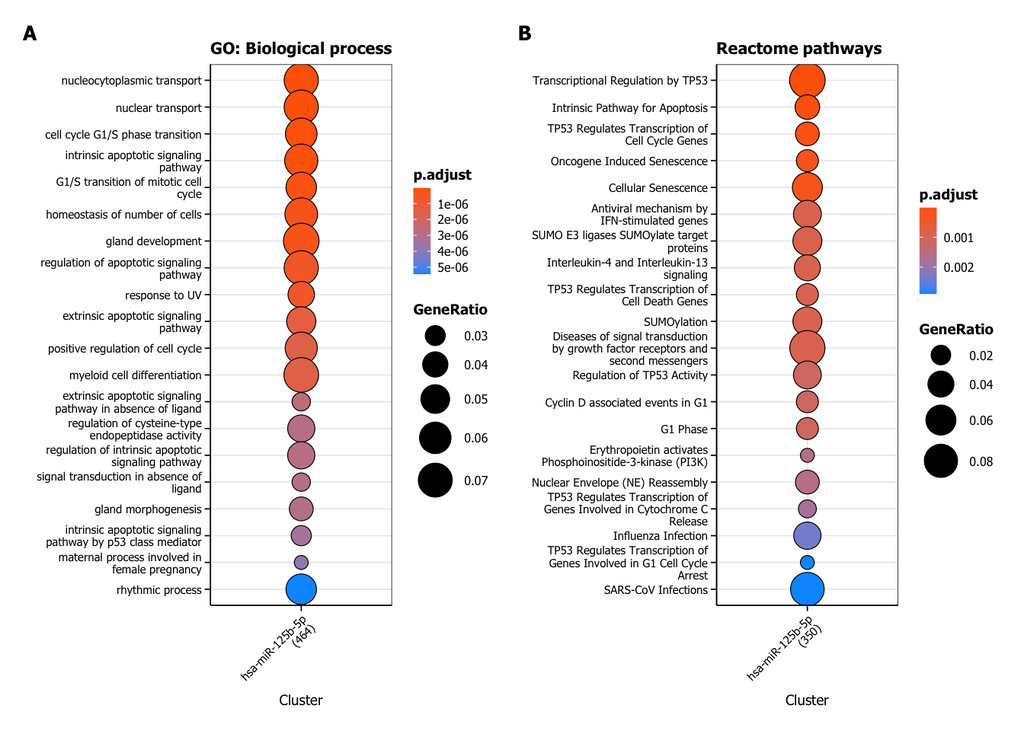

```r
safe_colors <- list(
  scale_color_gradient2(
    low = "grey90", mid = "#FF6600", high = "#0099FF",
    name = "p.adjust",
    guide = guide_colorbar(reverse = TRUE, order = 1)
  ),
  scale_fill_gradient2(
    low = "grey90", mid = "#FF6600", high = "#0099FF",
    name = "p.adjust",
    guide = guide_colorbar(reverse = TRUE, order = 1)
  )
)

journal_theme <- theme_bw(base_family = "Tahoma", base_size = 7) +
  theme(
    axis.text = element_text(color = "black"),
    axis.text.x = element_text(angle = 45, hjust = 1, vjust = 1),
    axis.line = element_line(color = "black", linewidth = 0.3),
    axis.ticks = element_line(color = "black", linewidth = 0.3),
    axis.ticks.length = unit(1, "mm"),
    plot.title = element_text(face = "bold", size = 8),
    legend.key.size = unit(3, "mm"),
    legend.title = element_text(size = 7, face = "bold"),
    legend.text = element_text(size = 6),
    panel.grid.minor = element_blank()
  )

p_go <- dotplot(go_compare, showCategory = 20, label_format = 35) +
  ggtitle("GO: Biological process") +
  safe_colors +
  journal_theme +
  guides(size = guide_legend(order = 2))

p_reactome <- dotplot(comp_reactome, showCategory = 20, label_format = 35) +
  ggtitle("Reactome pathways") +
  safe_colors +
  journal_theme +
  guides(size = guide_legend(order = 2))

final_plt <- (p_go | p_reactome) +
  plot_annotation(tag_levels = 'A') &
  theme(
    plot.tag = element_text(family = "Tahoma", face = "bold", size = 10),
    plot.margin = margin(2, 2, 2, 2, "mm"),
    panel.spacing = unit(4, "mm")
  )

ggsave("./pictures_transpl/126281-g004.png", plot = final_plt,
       width = 168, height = 150, units = "mm", dpi = 600, bg = "white")
ggsave("./pictures_transpl/126281-g004.svg", plot = final_plt,
       width = 168, height = 150, units = "mm", bg = "white")
final_plt
```

## Network Visualization

**Shared Target Filtering**

```r
df_shared <- df_val %>%
  dplyr::group_by(target_symbol) %>%
  dplyr::filter(dplyr::n_distinct(mature_mirna_id) >= 2) %>%
  dplyr::ungroup()
df_shared
```

| mature_mirna_id | target_symbol |
| --- | --- |
| hsa-miR-125b-5p | E2F3 |
| hsa-miR-125b-5p | CD44 |
| hsa-miR-125b-5p | BTG2 |
| hsa-miR-125b-5p | ABL1 |
| hsa-miR-125b-5p | NUP93 |
| hsa-miR-125b-5p | PABPC1 |
| hsa-miR-125b-5p | TMEM101 |
| hsa-miR-125b-5p | TOR2A |
| hsa-miR-125b-5p | ANKRD33B |
| hsa-miR-125b-5p | BACE2 |

[output cut: 18 more lines]

**Hub Gene Summary**

```r
df_shared_summary <- df_shared %>%
  dplyr::group_by(target_symbol) %>%
  dplyr::summarise(
    n_interactions = dplyr::n_distinct(mature_mirna_id),
    miRNAs = paste(unique(mature_mirna_id), collapse = "; "),
    .groups = "drop"
  ) %>%
  dplyr::arrange(desc(n_interactions))

df_shared_summary
```

| target_symbol | n_interactions | miRNAs |
| --- | --- | --- |
| ABL1 | 2 | hsa-miR-125b-5p; hsa-miR-5588-5p |
| ANKRD33B | 2 | hsa-miR-125b-5p; hsa-miR-193b-5p |
| APLN | 2 | hsa-miR-125b-5p; hsa-miR-193b-5p |
| BACE2 | 2 | hsa-miR-125b-5p; hsa-miR-193b-5p |
| BTG2 | 2 | hsa-miR-125b-5p; hsa-miR-193b-5p |
| CD44 | 2 | hsa-miR-125b-5p; hsa-miR-193b-5p |
| E2F3 | 2 | hsa-miR-125b-5p; hsa-miR-5588-5p |
| NUP93 | 2 | hsa-miR-125b-5p; hsa-miR-193b-5p |
| PABPC1 | 2 | hsa-miR-125b-5p; hsa-miR-5588-5p |
| RDH11 | 2 | hsa-miR-193b-5p; hsa-miR-5588-5p |

[output cut: 4 more lines]

**miRNA Interaction Frequency**

```r
gene_freq <- df_shared %>%
   dplyr::count(mature_mirna_id, name = "n_target") %>%
   dplyr::arrange(desc(n_target))

print(gene_freq)
```

```
## # A tibble: 3 × 2
##   mature_mirna_id n_target
##   <chr>              <int>
## 1 hsa-miR-125b-5p       11
## 2 hsa-miR-193b-5p       10
## 3 hsa-miR-5588-5p        7
```

**miRNA-mRNA Network Visualization, Figure 4**

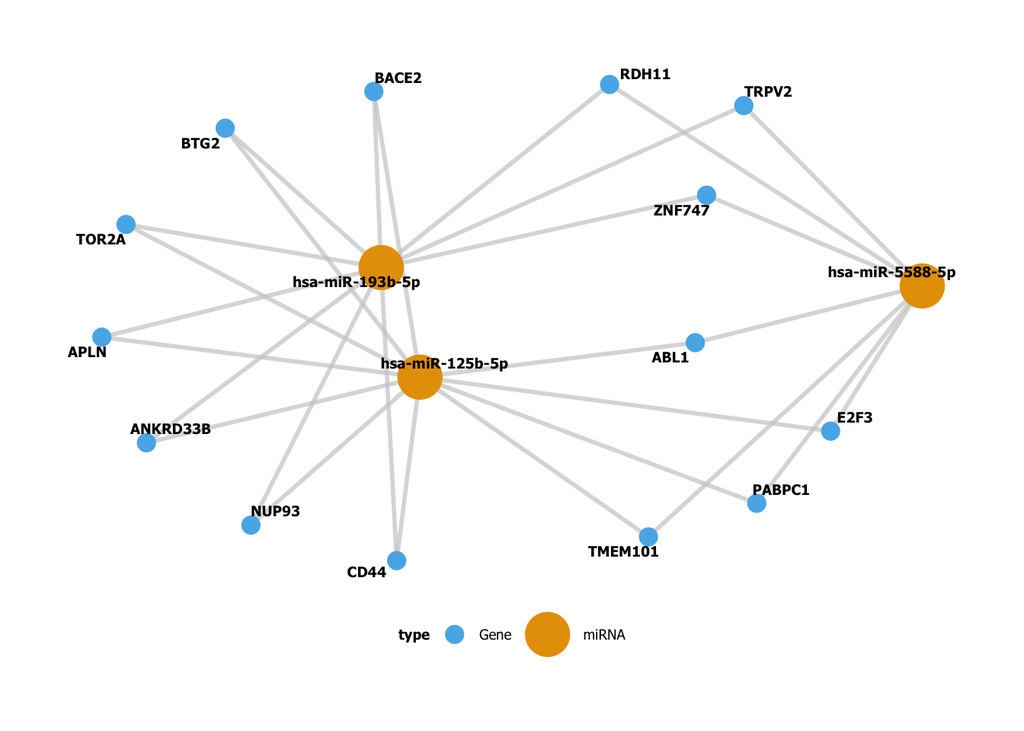

```r
g <- graph_from_data_frame(df_shared, directed = FALSE)

V(g)$type <- ifelse(V(g)$name %in% unique(df_shared$mature_mirna_id), "miRNA", "Gene")

set.seed(123)

plt <- ggraph(g, layout = "stress") +
  geom_edge_link0(color = "gray80", alpha = 0.7, width = 1) +
  geom_node_point(aes(color = type, size = type)) +

  scale_color_manual(values = c("Gene" = "#56B4E9", "miRNA" = "#E69F00")) +
  scale_size_manual(values = c("Gene" = 4, "miRNA" = 10)) +

  geom_node_text(
    aes(label = name),
    repel = TRUE,
    size = 2.5,
    fontface = "bold",
    color = "black",
    family = "Tahoma"
  ) +

  theme_graph(base_family = "Tahoma", base_size = 7) +
  theme(
    legend.position = "bottom",
    plot.title = element_text(hjust = 0.5, face = "bold", size = 8),
    legend.title = element_text(face = "bold", size = 7),
    legend.text = element_text(size = 7)
  )

print(plt)
```

```r
ggsave("./pictures_transpl/126281-g005.png", plot = plt,
       width = 168, height = 140, units = "mm", dpi = 600, bg = "white")
ggsave("./pictures_transpl/126281-g005.svg", plot = plt,
       width = 168, height = 140, units = "mm", dpi = 600, bg = "white")
```